# Biased and unbiased estimators test

Imagine we have a deterministic function $f(x)$ where $x$ is a random variable with probability $p(x)$. We are often interested in the expectation of $f(x)$. The definition of this expectation is:

$$\mathbb{E}[f(x)] = \int f(x)p(x) \text{d}x$$

The expectation is no more than the weighted integral of the function, where the weights are given by the probability of each point $x$. Imagine that we cannot solve this integral, or that we do not know $p(x)$, but we have some samples $x^{(j)} \sim p(x)$.

**Unbiased estimator**

We can propose an estimator based of the samples of $x$:

$$\mathbb{E}[f(x)] \approx \frac{1}{J}\sum_j f(x^{(j)})$$

We say that the estimator is unbiased if its expectation correspond to the parameter it wants to estimate. This can be easily checked:

$$\mathbb{E}[\frac{1}{J}\sum_j f(x^{(j)})] =
\frac{1}{J}\sum_j \mathbb{E} [f(x^{(j)})] =
\frac{1}{J}J \mathbb{E} [f(x)] =
\mathbb{E} [f(x)]$$

```r
# Estimate the mean of a Gaussian random variable
# f(x) = x
# p(x) = f(x)
library(tidyr)
library(ggplot2)
my_function <- function(x){
  x
}
my_pdf <- function(x){
  dnorm(x, mean = 0, sd = 1)
}
x_samples <- rnorm(n = 10000, mean = 0, sd = 1)
expectation <- sum(my_function(x_samples))/10000
cat("Est. Expectation:", expectation)
```

```
Est. Expectation: -0.003151942
```

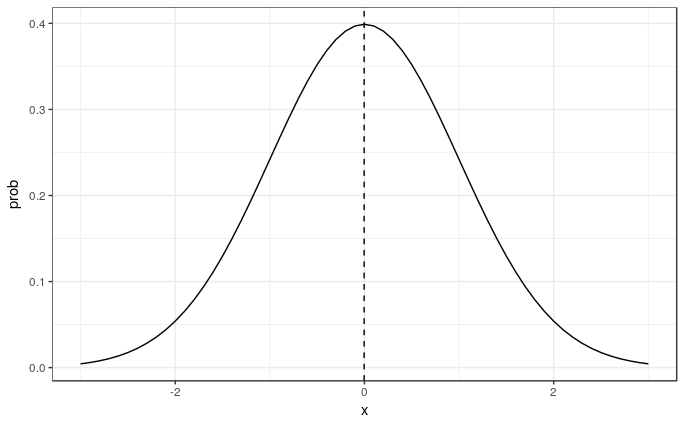

```r
x      <-seq(-3,3, by=0.1)
prob  <- my_pdf(x)
y <- my_function(x)
df <- data.frame(x = x, prob = prob)
ggplot(df, aes(x = x, y = prob)) +
  geom_line() +
  geom_vline(aes(xintercept = expectation), linetype = 2) +
  theme_bw()
```

**Biased estimators**

Imagine now that we want to estimate the log of the expectation $f(x)$ and that we approximate this as

$$\log \mathbb{E}[f(x)] \approx \log \big(\frac{1}{J}\sum_j f(x^{(j)})\big)$$

And now let’s see whether it is biased or unbiased (we will use Jensen’s [inequality](http://mark.reid.name/blog/behold-jensens-inequality.html)):

$$\mathbb{E}\big[ \log \big(\frac{1}{J}\sum_j f(x^{(j)})\big)\big]
\leq
\log \mathbb{E}\big[\frac{1}{J}\sum_j f(x^{(j)})\big]
=
\log \mathbb{E}[f(x)]$$

Aha! This estimator is biased and, more specifically, it underestimates the true value.

```r
# Estimate the log of the mean of a Gaussian random variable
# f(x) = x
# p(x) = f(x)
# mean is 1, E log 1 = 0 TDOO find clear example
library(tidyr)
library(ggplot2)
my_function <- function(x){
  x
}
my_pdf <- function(x){
  dnorm(x, mean = 0, sd = 1)
}
x_samples <- rnorm(n = 10000, mean = 0, sd = 10)
expectation <- log(sum(my_function(x_samples))/10000)
```

```
Se han producido NaNs
```

```r
cat("Est. Expectation:", expectation)
```

```
Est. Expectation: NaN
```

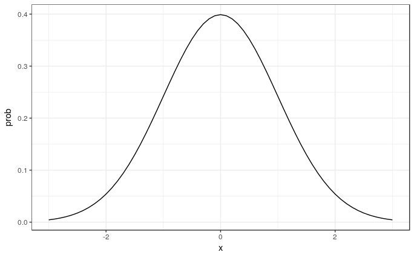

```r
x      <-seq(-3,3, by=0.1)
prob  <- my_pdf(x)
y <- my_function(x)
df <- data.frame(x = x, prob = prob)
ggplot(df, aes(x = x, y = prob)) +
  geom_line() +
  geom_vline(aes(xintercept = expectation), linetype = 2) +
  theme_bw()
```